# Open Data Network Business Intelligence Report

Data-Driven Management Analysis

Derrick Bekibele, 667978912

Ani Rodriguez, 655485829

Sovandy Por, 667282701

Hakim Bah,656590759

2025-11-25

# Executive Summary

This report analyzes a health insurance dataset to understand how demographic and behavioral factors influence insurance costs. After importing the dataset using the CSV download method, a data quality review confirmed complete and reliable records, with no missing values across key variables such as age, BMI, region, smoking status, and charges.

Exploratory analysis shows that BMI follows a normal distribution, and the population is evenly distributed across regions and gender. The most significant finding is the large cost difference between smokers and non smokers. While insurance charges rise gradually with age for non smokers, smokers show consistently higher costs at every age range, indicating smoking is the strongest predictor of elevated insurance expenses.

These insights suggest that high risk customer groups can be identified using this dataset. The results support data-driven strategies such as risk based pricing, targeted smoking cessation programs, and preventative health initiatives to reduce long term claims and improve financial outcomes for the insurance provider.

## Section 1

A health insurance company needs to determine how customer characteristics such as age, BMI, and smoking status affect insurance cost differences. The goal is to identify which customer groups create the highest financial risk and whether pricing adjustments or targeted wellness programs are needed. This dataset is suitable because it includes cost information and key demographic variables, allowing data-driven predictions and comparisons across customer segments.

## Section 2

```r
# Load ggplot2
library(ggplot2)

# Load the business dataset
business_data <- read.csv("insurance.csv.csv")
```

### 2.a

The dataset used in this report is the Medical Insurance Cost Dataset, accessed from Kaggle: https://www.kaggle.com/datasets/mosapabdelghany/medical-insurance-cost- dataset. It was published in 2025 by Mosap Abdel-Ghany on the Kaggle platform. The original data-collecting organization is not identified; however, based on the dataset structure and its application in regression and machine learning tutorials, the likely purpose of data collection was research, educational use, and healthcare cost prediction modeling. The dataset contains information on 1,338 individuals and represents a general adult population from the United States, including the number of dependent children covered under each insurance policy. The original period of data collection is not specified, although the dataset is listed as never updated, making it a static dataset. Key limitations include the absence of documented collection methodology, lack of transparency regarding original data sources, and potential lack of alignment with current healthcare cost conditions and policies.

### 2.b

The dataset was accessed through a manual CSV download from the Kaggle platform and imported into RStudio for analysis. After downloading the file, it was saved locally on the working device and loaded into the R environment using the read.csv() function. The dataset was imported using the following command: business_data

read.csv("insurance.csv.csv"). This method was selected because it aligns with common business intelligence workflows in introductory analytics and e-management courses, where datasets are processed offline for exploratory analysis and visualization. It also ensured full control over the local data file and allowed seamless integration with R packages such as ggplot2 for graphical analysis. Since the dataset is static and does not require live updates, an API connection was not necessary.

### 2.c

```r
# Required data quality analysis
dim(20) # Verify rows > 500 and columns >= 5
```

[output not shown]

```r
str(business_data) # Check variable types (numeric vs categorical)
```

```
## 'data.frame':    1338 obs. of  7 variables:
##  $ age     : int  19 18 28 33 32 31 46 37 37 60 ...
##  $ sex     : chr  "female" "male" "male" "male" ...
##  $ bmi     : num  27.9 33.8 33 22.7 28.9 ...
##  $ children: int  0 1 3 0 0 0 1 3 2 0 ...
##  $ smoker  : chr  "yes" "no" "no" "no" ...
##  $ region  : chr  "southwest" "southeast" "southeast" "northwest" ...
##  $ charges : num  16885 1726 4449 21984 3867 ...
```

```r
# Data completeness
colSums(is.na(business_data))
```

```
##      age      sex      bmi children   smoker   region  charges
##        0        0        0        0        0        0        0
```

```r
# Percentage of missing values per column
(colSums(is.na(business_data)) / nrow(business_data)) * 100
```

```
##      age      sex      bmi children   smoker   region  charges
##        0        0        0        0        0        0        0
```

```r
sapply(business_data, function(x) length(unique(x)))
```

```
##      age      sex      bmi children   smoker   region  charges
##       47        2      548        6        2        4     1337
```

## Section 3

### 3.a

```r
# Calculate totals first
aggregate(bmi ~ sex, data = business_data, mean)
```

```
##      sex      bmi
## 1 female 30.37775
## 2   male 30.94313
```

```r
table (business_data$smoker)
```

```
##
##   no  yes
## 1064  274
```

Using aggregate(bmi ~ sex, data = business_data, mean), we find that average BMI is 30.38 for females and 30.94 for males, indicating similar weight-related risk across genders. The table(business_data$smoker) function shows 274 smokers and 1,064 non-smokers, meaning only about 20% of insured adults smoke. For an insurance provider, this suggests that smoking status, rather than gender, may be a more critical factor for pricing and risk assessment.

### 3.b

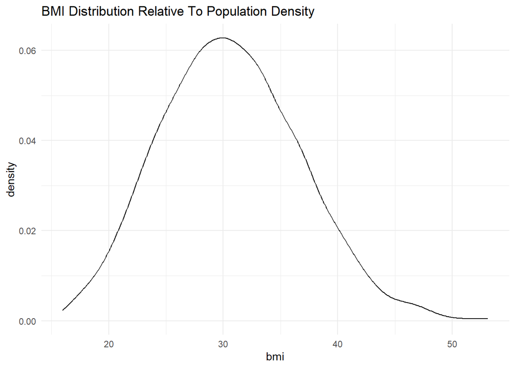

```r
gg <-ggplot(data = business_data) +
  theme_minimal()

gg+ geom_density(aes(x=bmi), colour="#000000")+xlab("bmi")+ylab("density")+ggtitle("BMI Distribution Relative To Population Density")
```

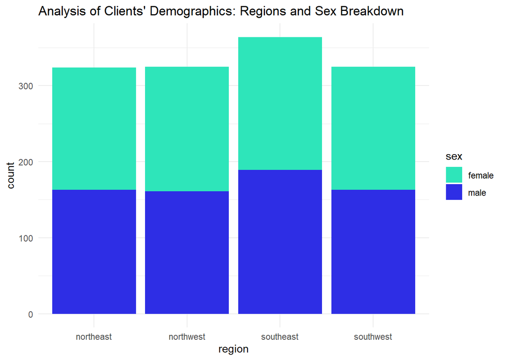

```r
gg+ geom_bar( aes(x=region, fill=sex))+xlab("region")+ylab("count")+ggtitle("Analysis of Clients' Demographics: Regions and Sex Breakdown")+scale_fill_manual(values =c("#2ee5ba","#2e2ee5"))
```

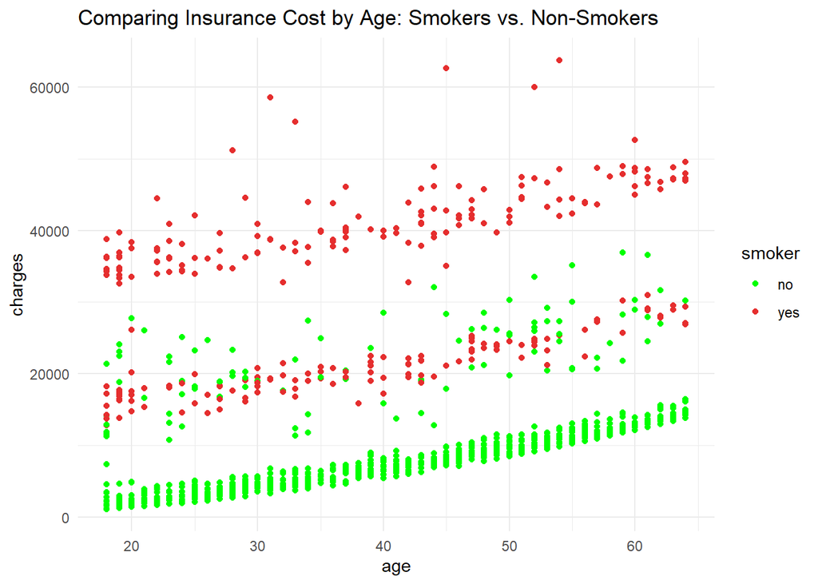

```r
gg+ geom_point(aes(x=age,y=charges,colour=smoker))+xlab("age")+ylab("charges")+ggtitle("Comparing Insurance Cost by Age: Smokers vs. Non-Smokers")+scale_colour_manual(values =c("green","#e52e2e"))
```

Visualization 1 – BMI Density Plot The distribution peaks around a BMI of 30, showing most clients fall into the overweight or obese range. This suggests higher long-term health risks and potential future cost pressures for insurers.

Visualization 2 – Region & Sex Bar Chart Client distribution is fairly balanced across all four regions, with the Southeast slightly higher. Gender proportions appear similar across regions, indicating no strong regional gender bias.

Visualization 3 – Age vs Charges Scatterplot Insurance charges rise with age, but smokers consistently pay much more at every age level. Smoking is clearly a major cost driver.

## 3.c

Pattern 1: Smoking and Insurance Costs Across all age groups, smokers consistently face significantly higher insurance charges than non-smokers. Based on the scatter plot, many smokers pay over $40,000 annually, while most non-smokers remain below $20,000. This shows that smoking status is a major cost driver and strongly influences insurance pricing.

## Section 4

Key Findings Summary